# QC and filter seurat object

```r
library(Seurat)
library(dplyr)
library(ggplot2)
library(RColorBrewer)
library(patchwork)
```

```r
# Set working directory to project root
setwd(gsub("/script/seurat", "", getwd()))
```

```r
# Source files
source("plotting_global.R")
```

# Parameter settings

```r
# Filtering Parameter
nFeature_RNA_min_m <- 250
nFeature_RNA_min_p <- 500

nFeature_RNA_max_m <- 4000
nFeature_RNA_max_p <- 4000

nCount_RNA_min_m <- 1000
nCount_RNA_min_p <- 1500

nCount_RNA_max_m <- 20000
nCount_RNA_max_p <- 20000

pMt_RNA_max_m <- 5
pMt_RNA_max_p <- 5

# Files
so_raw_file <- "data/seurat_object/so_raw.rds"
so_qc_file <- "data/seurat_object/so_qc.rds"

# Plotting Theme
ggplot2::theme_set(theme_global_set()) # From project global source()
```

# Import Seurat object

```r
so_raw <- readRDS(so_raw_file)
```

# Add filter meta data to Seurat object

```r
so_raw$nFeature_RNA_max <- ifelse(so_raw$tissue == "Myeloid", nFeature_RNA_max_m, nFeature_RNA_max_p)
so_raw$nFeature_RNA_min <- ifelse(so_raw$tissue == "Myeloid", nFeature_RNA_min_m, nFeature_RNA_min_p)

so_raw$nCount_RNA_max <- ifelse(so_raw$tissue == "Myeloid", nCount_RNA_max_m, nCount_RNA_max_p)
so_raw$nCount_RNA_min <- ifelse(so_raw$tissue == "Myeloid", nCount_RNA_min_m, nCount_RNA_min_p)

so_raw$pMt_RNA_max <- ifelse(so_raw$tissue == "Myeloid", pMt_RNA_max_m, pMt_RNA_max_p)

# QC
so_raw$qc_class <- ifelse(
  so_raw$cellranger_class == "Cell" &
    so_raw$nFeature_RNA <= so_raw$nFeature_RNA_max &
    so_raw$nFeature_RNA >= so_raw$nFeature_RNA_min &
    so_raw$nCount_RNA <= so_raw$nCount_RNA_max &
    so_raw$nCount_RNA >= so_raw$nCount_RNA_min &
    so_raw$pMt_RNA <= so_raw$pMt_RNA_max,
  "pass", "fail"
  )
```

# Filter cells by rank plot

Empty droplets were determined with CellRanger V3.0.2 Lun et al., 2019 EmptyDrop heuristic. RNAse activity of granulocytes might be wrongly identified as empty cells by CellRanger.

**Typical Sample** A steep drop-off is indicative of good separation between the cell-associated barcodes and the barcodes associated with empty GEMs. A ideal barcode rank plot has a distincitve shape, which is referred to as a "cliff and knee".

**Heterogeneous Sample** Heterogeneous populations of cells in a sample result in two "cliff and knee" distributions. However, there should still be clear separation between the bacodes.

**Compromised Sample** Round curve and lack of steep cliff may indicate low sample quality or loss of single-cell behavior. This can be due to a wetting failure, premature cell lysis, or low cell viability.

**Compromised Sample** Defined cliff and knee, but the total number of barcodes detected may be lower than expected. This can be caused by a sample clog or inaccurate cell count.

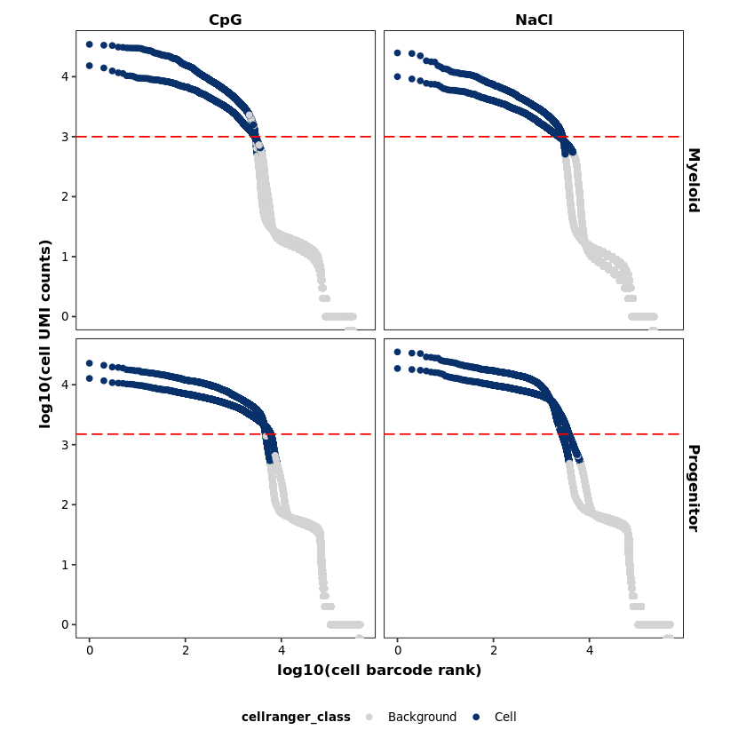

```r
rank_plot <- ggplot(so_raw@meta.data, aes(x = log10(nCount_RNA_rank), y = log10(nCount_RNA), color = cellranger_class)) +
  geom_point() +
  geom_hline(aes(yintercept = log10(nCount_RNA_min)), color = "red", linetype = "longdash") +
  scale_color_manual(values = so_color$cellranger_class) +
  ggtitle("Barcode rank plot") +
  xlab("log10(cell barcode rank)") + ylab("log10(cell UMI counts)") +
  facet_grid(tissue~treatment) +
  theme(aspect.ratio = 1, legend.position = "bottom")

rank_plot
ggsave(rank_plot, filename = "result/plot/seurat/rank_plot.png", width = 4, height = 4)
```

# Filter by cell_ranger class

```r
so_qc <- subset(so_raw, subset = cellranger_class == "Cell")
```

```r
# Filter by UMI and Feature count
```

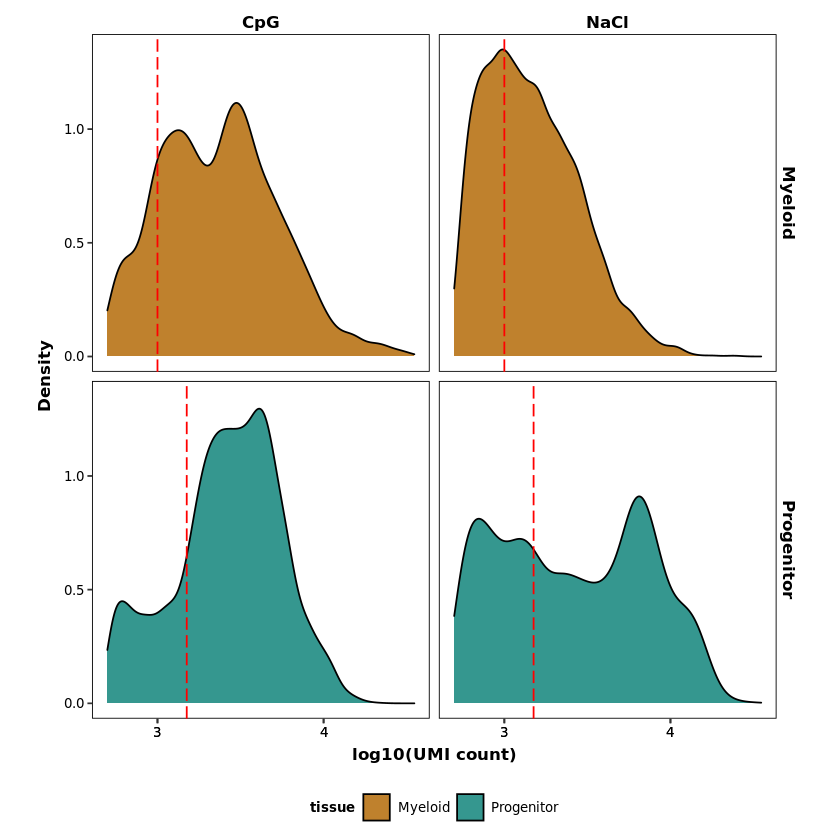

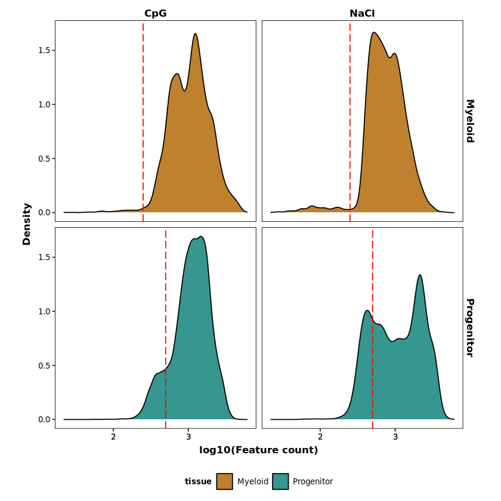

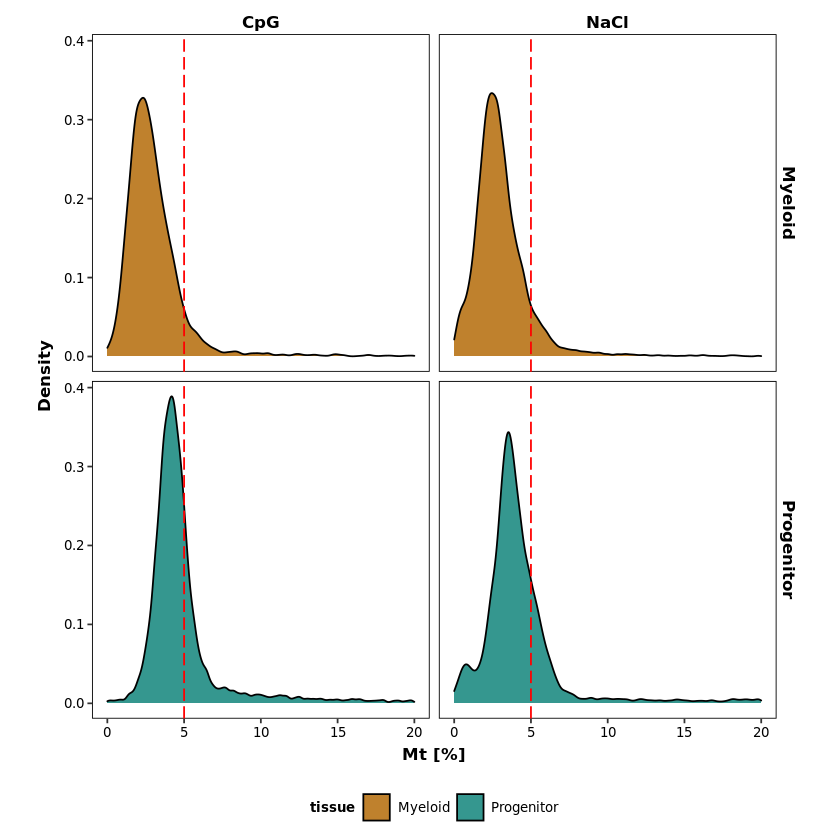

```r
qc_1 <- ggplot(so_qc@meta.data, aes(x = log10(nCount_RNA), fill = tissue)) +
  geom_density() +
  ggtitle("Density plot UMI count") + xlab("log10(UMI count)") + ylab("Density") +
  geom_vline(aes(xintercept = log10(nCount_RNA_min)), color = "red", linetype = "longdash") +
  scale_x_continuous(breaks = integer_breaks()) +
  scale_fill_manual(values = so_color$tissue) +
  facet_grid(tissue~treatment) +
  theme(legend.position = "bottom", aspect.ratio = 1)

qc_2 <- ggplot(so_qc@meta.data, aes(x = log10(nFeature_RNA), fill = tissue)) +
  geom_density() +
  ggtitle("Density plot Feature count") + xlab("log10(Feature count)") + ylab("Density") +
  geom_vline(aes(xintercept = log10(nFeature_RNA_min)), color = "red", linetype = "longdash") +
  scale_x_continuous(breaks = integer_breaks()) +
  scale_fill_manual(values = so_color$tissue) +
  facet_grid(tissue~treatment) +
  theme(legend.position = "bottom", aspect.ratio = 1)

qc_3 <- ggplot(so_qc@meta.data, aes(x = pMt_RNA, fill = tissue)) +
  geom_density() +
  ggtitle("Density plot Mt %") + xlab("Mt [%]") + ylab("Density") +
  geom_vline(aes(xintercept = pMt_RNA_max), color = "red", linetype = "longdash") +
  scale_x_continuous(breaks = integer_breaks()) +
  xlim(0, 20) +
  scale_fill_manual(values = so_color$tissue) +
  facet_grid(tissue~treatment)  +
  theme(legend.position = "bottom", aspect.ratio = 1)

qc_1
qc_2
qc_3

ggsave(qc_1, filename = "result/plot/seurat/density_umi.png", width = 4, height = 4)
ggsave(qc_2, filename = "result/plot/seurat/density_feature.png", width = 4, height = 4)
ggsave(qc_3, filename = "result/plot/seurat/density_mt.png", width = 4, height = 4)
```

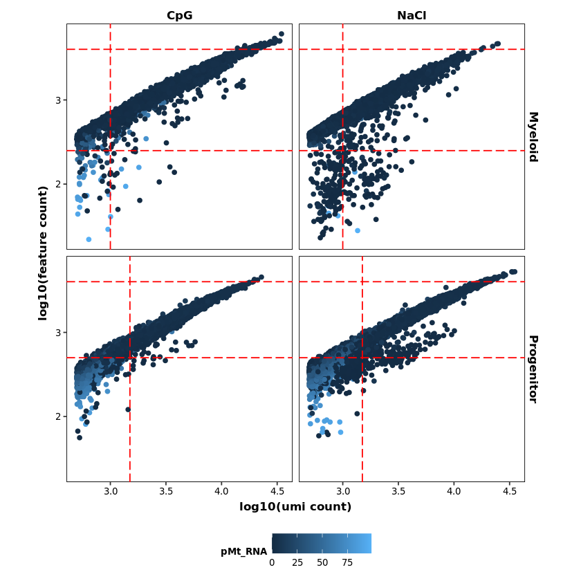

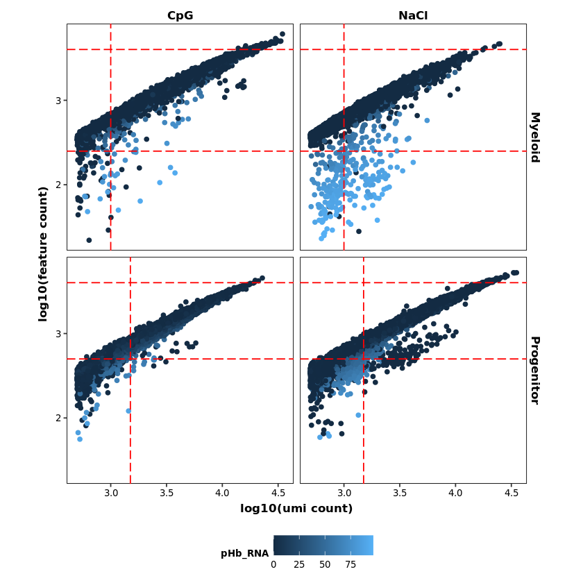

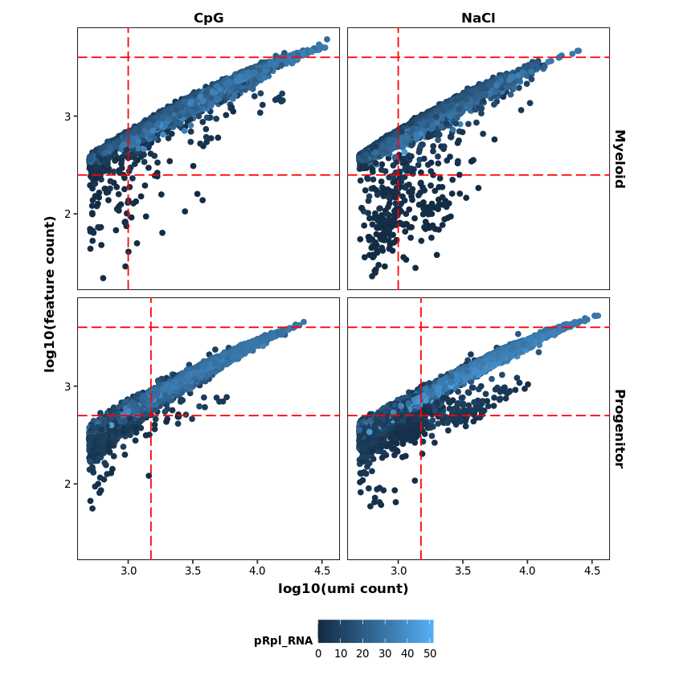

```r
sc_1 <- ggplot(so_qc@meta.data, aes(x = log10(nCount_RNA), y = log10(nFeature_RNA), color = pMt_RNA)) +
  geom_point() + ggtitle("Mitochondrial gene percentage") + ylab("log10(feature count)") + xlab("log10(umi count)") +
  geom_vline(aes(xintercept = log10(nCount_RNA_min)), color = "red", linetype = "longdash") +
  #geom_vline(aes(xintercept = log10(nCount_RNA_max)), color = "red", linetype = "longdash") +
  geom_hline(aes(yintercept = log10(nFeature_RNA_min)), color = "red", linetype = "longdash") +
  geom_hline(aes(yintercept = log10(nFeature_RNA_max)), color = "red", linetype = "longdash") +
  facet_grid(tissue~treatment) + theme(aspect.ratio = 1, legend.position = "bottom") +
  scale_size(guide = guide_legend(direction = "vertical"))

sc_2 <- ggplot(so_qc@meta.data, aes(x = log10(nCount_RNA), y = log10(nFeature_RNA), color = pHb_RNA)) +
  geom_point() + ggtitle("Hemoglobin gene percentage") + ylab("log10(feature count)") + xlab("log10(umi count)") +
  geom_vline(aes(xintercept = log10(nCount_RNA_min)), color = "red", linetype = "longdash") +
  #geom_vline(aes(xintercept = log10(nCount_RNA_max)), color = "red", linetype = "longdash") +
  geom_hline(aes(yintercept = log10(nFeature_RNA_min)), color = "red", linetype = "longdash") +
  geom_hline(aes(yintercept = log10(nFeature_RNA_max)), color = "red", linetype = "longdash") +
  facet_grid(tissue~treatment) + theme(aspect.ratio = 1, legend.position = "bottom") +
  scale_size(guide = guide_legend(direction = "vertical"))

sc_3 <- ggplot(so_qc@meta.data, aes(x = log10(nCount_RNA), y = log10(nFeature_RNA), color = pRpl_RNA)) +
  geom_point() + ggtitle("Ribsonmal gene percentage") + ylab("log10(feature count)") + xlab("log10(umi count)") +
  geom_vline(aes(xintercept = log10(nCount_RNA_min)), color = "red", linetype = "longdash") +
  #geom_vline(aes(xintercept = log10(nCount_RNA_max)), color = "red", linetype = "longdash") +
  geom_hline(aes(yintercept = log10(nFeature_RNA_min)), color = "red", linetype = "longdash") +
  geom_hline(aes(yintercept = log10(nFeature_RNA_max)), color = "red", linetype = "longdash") +
  facet_grid(tissue~treatment) + theme(aspect.ratio = 1, legend.position = "bottom") +
  scale_size(guide = guide_legend(direction = "vertical"))

sc_1
sc_2
sc_3

ggsave(sc_1, filename = "result/plot/seurat/sc_mt.png", width = 4, height = 4)
ggsave(sc_2, filename = "result/plot/seurat/sc_hg.png", width = 4, height = 4)
ggsave(sc_3, filename = "result/plot/seurat/sc_rb.png", width = 4, height = 4)
```

```r
so_qc <- subset(so_qc, subset =  nFeature_RNA >= nFeature_RNA_min & nFeature_RNA <= nFeature_RNA_max & nCount_RNA <= nCount_RNA_max & pMt_RNA <= pMt_RNA_max)
```

# Violine plots

```
Warning message:
“Removed 1 rows containing missing values (geom_point).”
```

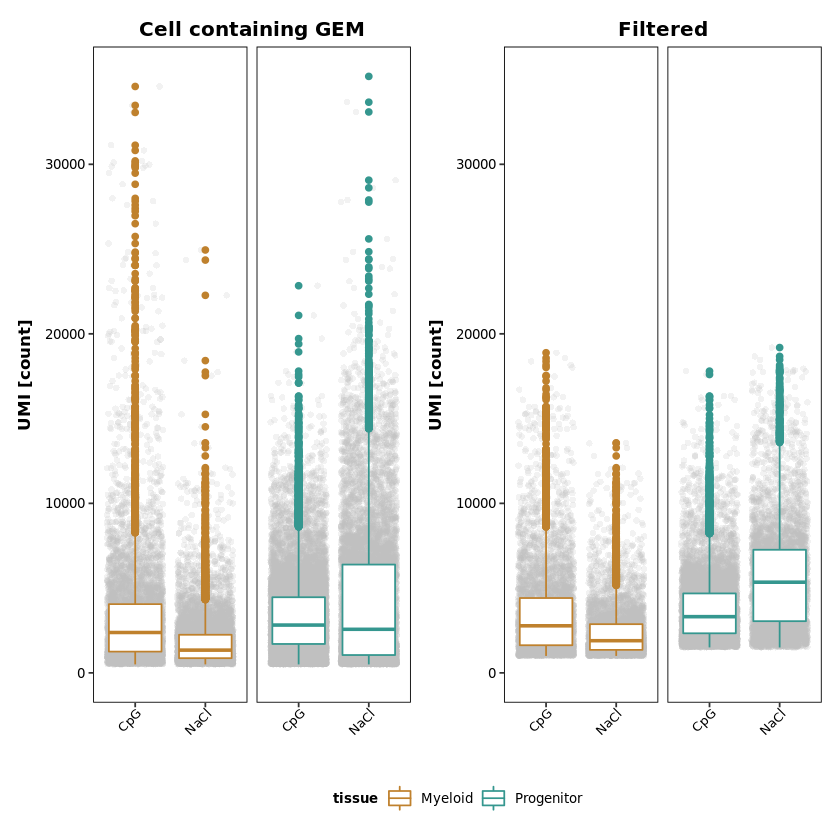

```
Warning message:
“Removed 30 rows containing missing values (geom_point).”
Warning message:
“Removed 2 rows containing missing values (geom_point).”
```

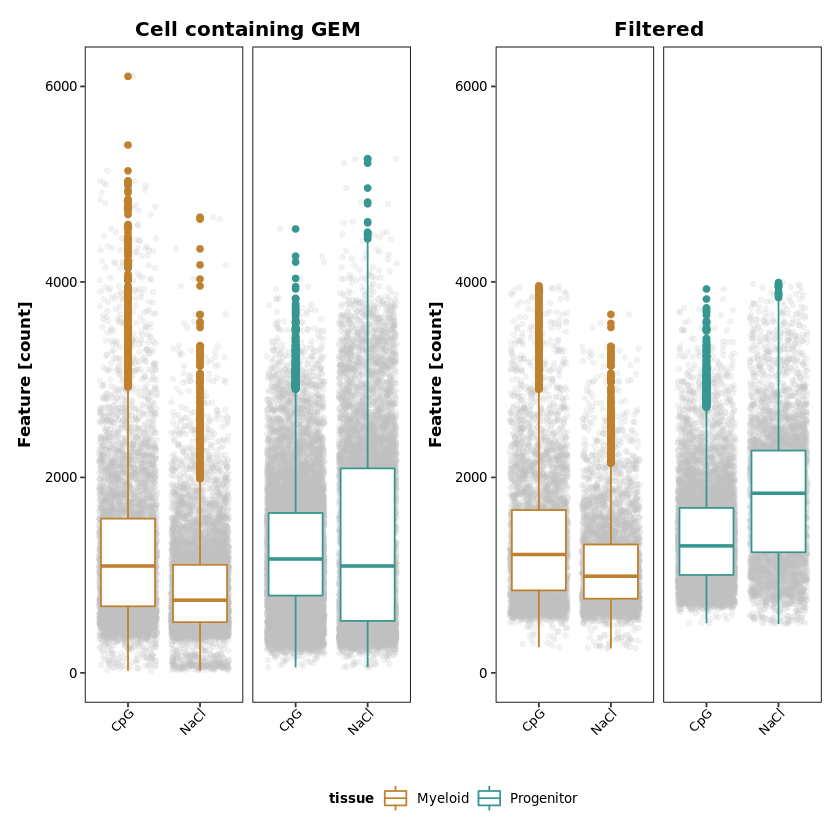

```
Warning message:
“Removed 6230 rows containing missing values (geom_point).”
Warning message:
“Removed 3908 rows containing missing values (geom_point).”
```

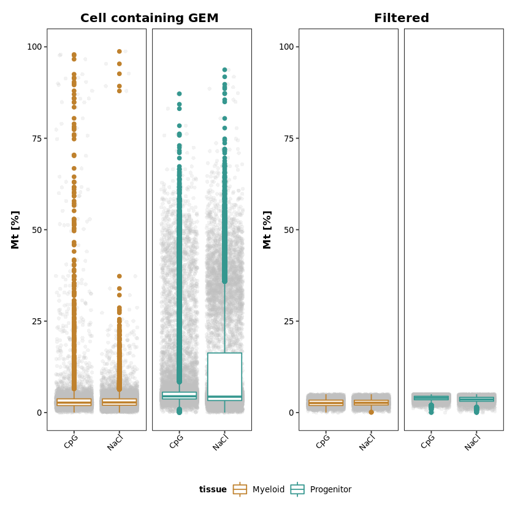

```
Warning message:
“Removed 6 rows containing missing values (geom_point).”
```

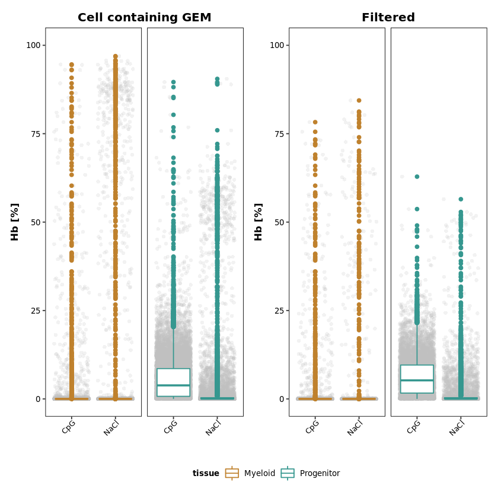

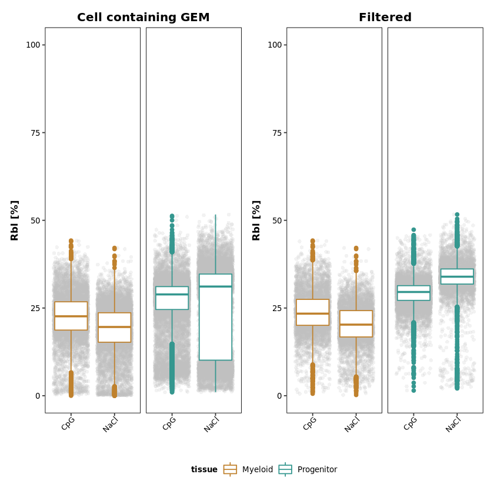

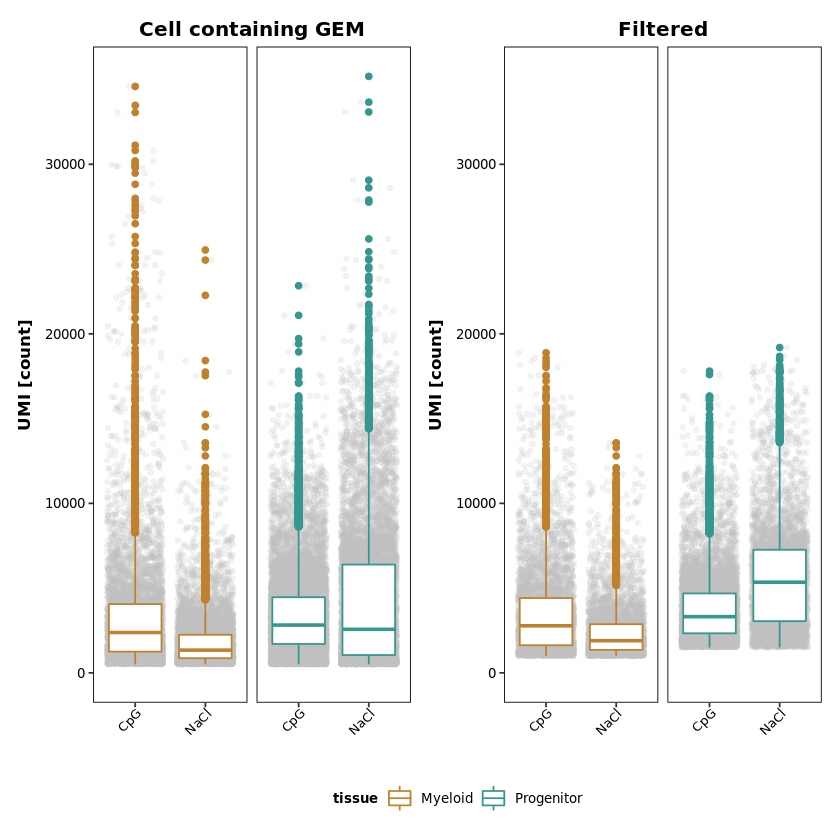

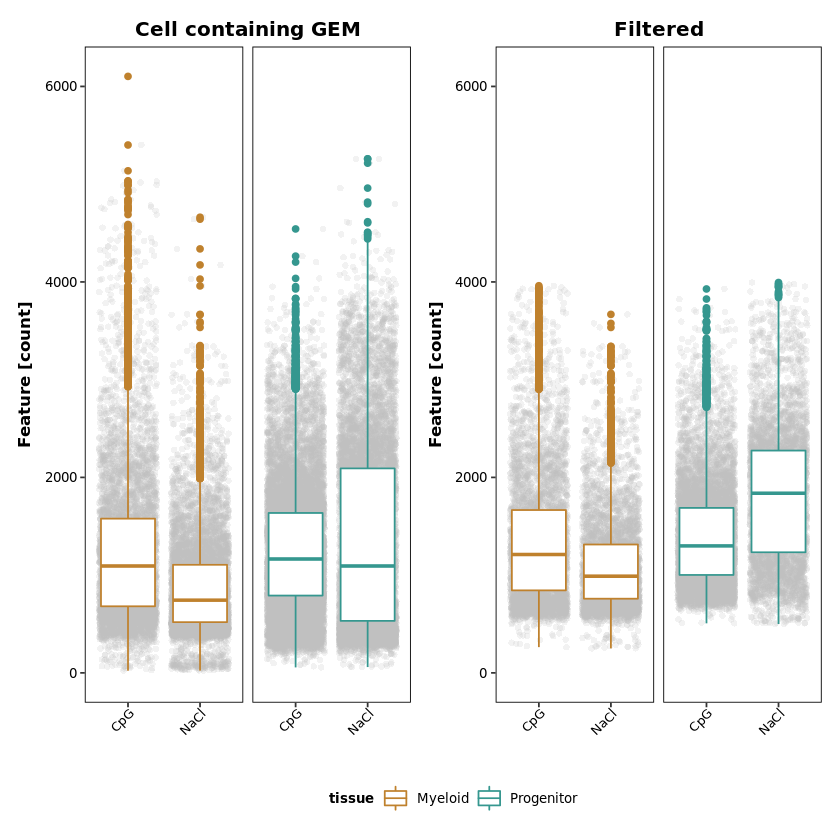

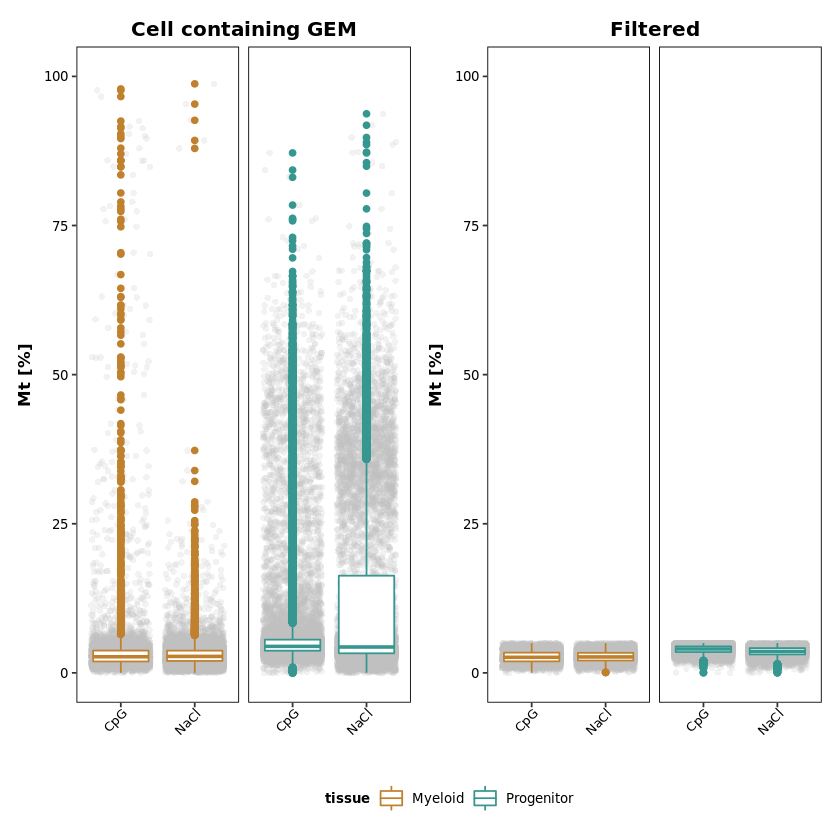

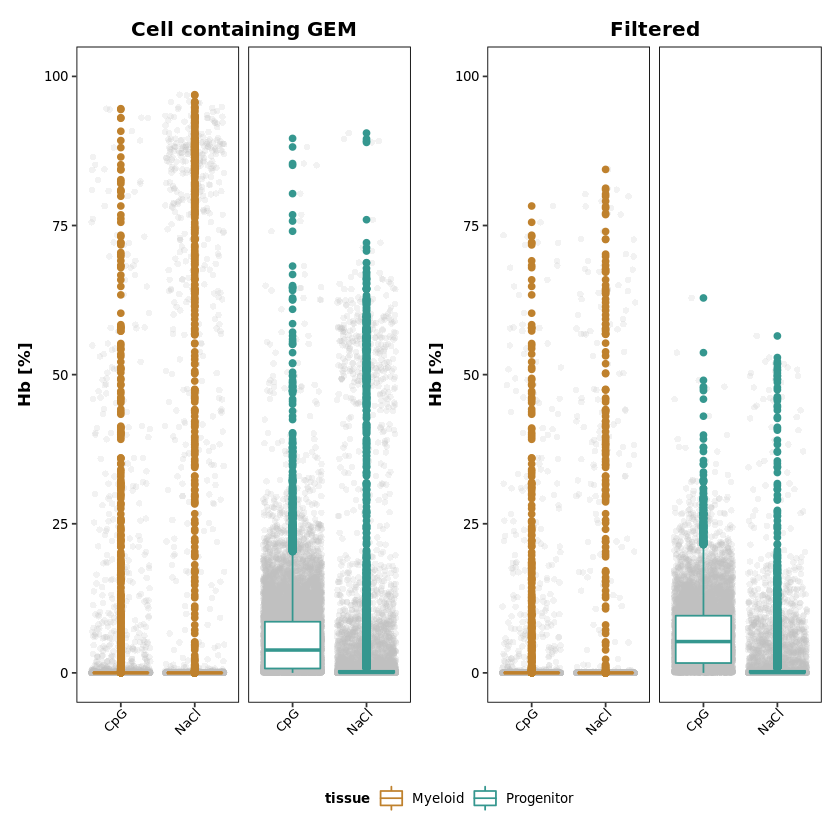

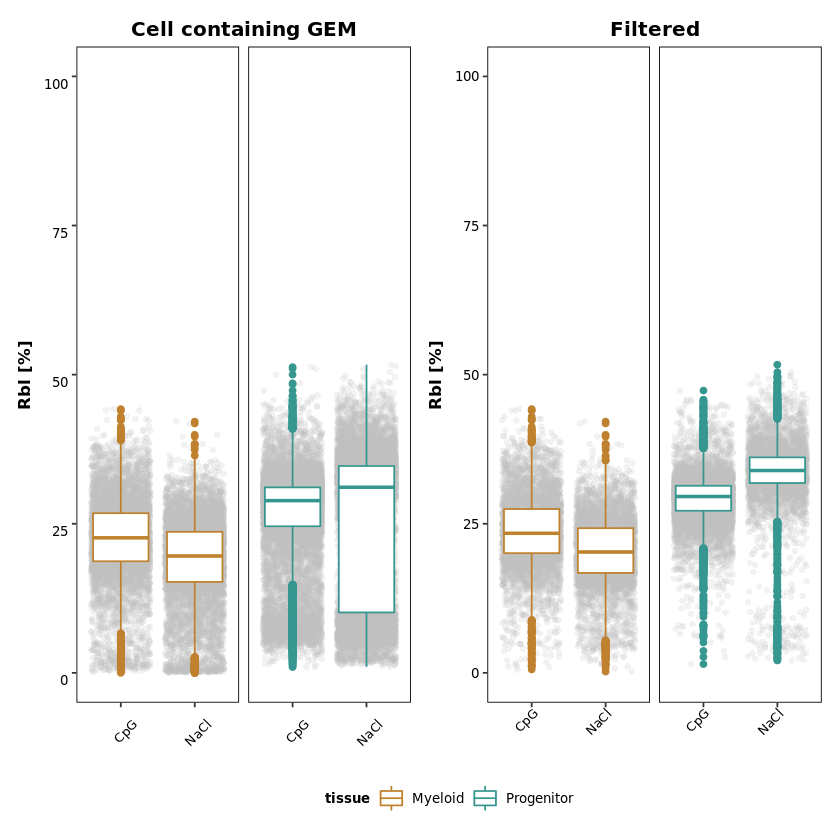

```r
qc_vln_FUN <- function(data, y, fill, ylab = "", scale_y_log10, ymin, ymax) {

  vln_plot_1 <- ggplot(data, aes(x = treatment, y = {{y}}, color = {{fill}})) +
    geom_jitter(alpha = 0.2, shape = 16, color = "gray") +
    geom_boxplot(alpha = 1.0) + xlab("") + ylim(ymin, ymax) +
    scale_color_manual(values = so_color$tissue) +
    ggtitle("Cell containing GEM") +
    facet_wrap(~tissue, scales = "free_x") + ylab(ylab) +
    theme(
      plot.title = element_text(size = 12, face = "bold", margin = margin(t = 0, r = 0, b = 5, l = 0)),
      axis.text.x = element_text(angle = 45, vjust = 1, hjust = 1),
      strip.text = element_blank()
      )

  vln_plot_2 <- ggplot(data[data$qc_class == "pass", ], aes(x = treatment, y = {{y}}, color = {{fill}})) +
    geom_jitter(alpha = 0.2, shape = 16, color = "gray") +
    geom_boxplot(alpha = 1.0) + xlab("") + ylim(ymin, ymax) +
    ylim(ymin, ymax) +
    scale_color_manual(values = so_color$tissue) +
    ggtitle("Filtered") +
    facet_wrap(~tissue, scales = "free_x") + ylab(ylab) +
    theme(
      plot.title = element_text(size = 12, face = "bold", margin = margin(t = 0, r = 0, b = 5, l = 0)),
      axis.text.x = element_text(angle = 45, vjust = 1, hjust = 1),
      strip.text = element_blank()
      )

  if(scale_y_log10) {

    vln_plot_1 <- vln_plot_1 + scale_y_log10(limits = c(ymin, NA))
    vln_plot_2 <- vln_plot_2 + scale_y_log10(limits = c(ymin, NA))

    }

  vln_plot <- vln_plot_1 + vln_plot_2 + plot_layout(ncol = 2, guides = "collect") & theme(legend.position = "bottom")

  plot(vln_plot)

  return(vln_plot)

}

so_cell <- subset(so_raw, subset = cellranger_class == "Cell")

qc_vln_1 <- qc_vln_FUN(so_cell@meta.data, nCount_RNA, tissue, "UMI [count]", FALSE, ymin = 0, ymax = max(so_cell$nCount_RNA))
qc_vln_2 <- qc_vln_FUN(so_cell@meta.data, nFeature_RNA, tissue, "Feature [count]", FALSE, ymin = 0, ymax = max(so_cell$nFeature_RNA))
qc_vln_3 <- qc_vln_FUN(so_cell@meta.data, pMt_RNA, tissue, "Mt [%]", FALSE, ymin = 0, ymax = 100)
qc_vln_4 <- qc_vln_FUN(so_cell@meta.data, pHb_RNA, tissue, "Hb [%]", FALSE, ymin = 0, ymax = 100)
qc_vln_5 <- qc_vln_FUN(so_cell@meta.data, pRpl_RNA, tissue, "Rbl [%]", FALSE, ymin = 0, ymax = 100)

qc_vln_1
qc_vln_2
qc_vln_3
qc_vln_4
qc_vln_5

ggsave(qc_vln_1, filename = "result/plot/seurat/qc_vln_1.png", width = 5, height = 2.5)
ggsave(qc_vln_2, filename = "result/plot/seurat/qc_vln_2.png", width = 5, height = 2.5)
ggsave(qc_vln_3, filename = "result/plot/seurat/qc_vln_3.png", width = 5, height = 2.5)
ggsave(qc_vln_4, filename = "result/plot/seurat/qc_vln_4.png", width = 5, height = 2.5)
ggsave(qc_vln_5, filename = "result/plot/seurat/qc_vln_5.png", width = 5, height = 2.5)

rm(so_cell)
```

# Cell cycle

```r
cc_kowalczyk <- read.csv("cc_kowalczyk.csv")
cc_kowalczyk <- cc_kowalczyk[cc_kowalczyk$sig_population >= 5, ]

cc_kowalczyk_g0 <- cc_kowalczyk[cc_kowalczyk$state == "down", ]
cc_kowalczyk_int <- cc_kowalczyk[cc_kowalczyk$state == "up", ]

cc_kowalczyk_s <- cc_kowalczyk_int[cc_kowalczyk_int$S > cc_kowalczyk_int$G2_M, ]
cc_kowalczyk_g2m <- cc_kowalczyk_int[cc_kowalczyk_int$G2_M > cc_kowalczyk_int$S, ]

so_qc <- CellCycleScoring(so_qc, s.features = cc_kowalczyk_s$gene, g2m.features = cc_kowalczyk_g2m$gene, set.ident = FALSE)
colnames(so_qc@meta.data) <- gsub("Phase", "cc_phase_class", colnames(so_qc@meta.data))
colnames(so_qc@meta.data) <- gsub("S.Score", "msS_RNA", colnames(so_qc@meta.data))
colnames(so_qc@meta.data) <- gsub("G2M.Score", "msInt_RNA", colnames(so_qc@meta.data))
so_qc$msCC_diff_RNA <- so_qc$msS_RNA - so_qc$msInt_RNA

so_qc <- AddModuleScore(so_qc, features = list(cc_kowalczyk_g0$gene), assays = "RNA", slot = "data", ctrl = 100, nbin = 25, name = "msG0_RNA")
so_qc <- AddModuleScore(so_qc, features = list(cc_kowalczyk_int$gene), assays = "RNA", slot = "data", ctrl = 100, nbin = 25, name = "msInt_RNA")
```

# Normalize

```r
so_qc <- NormalizeData(
  object               = so_qc,
  assay                = "RNA",
  normalization.method = "LogNormalize",
  scale.factor         = 10000
  )
```

# Variable feature selection

```r
so_qc <- FindVariableFeatures(
  object           = so_qc,
  assay            = "RNA",
  selection.method = "vst",
  nfeatures        = 2000
  )
```

# Remove cell cycle variable feature

```r
variable_features <- VariableFeatures(so_qc)
VariableFeatures(so_qc) <- variable_features[!variable_features %in% c(cc_kowalczyk$gene)]
```

# Scale data

Regress nCount_RNA (total UMI per cell) and pMT_RNA (mitochondrial UMI percentage)

```r
so_qc <- ScaleData(
  object          = so_qc,
  assay           = "RNA",
  vars.to.regress = c("nCount_RNA", "pMt_RNA"),
  do.scale        = TRUE,
  do.center       = TRUE
  )
```

# Dim reduction

```r
dim_clust <- function(

  # Seurat
  so,
  assay = NULL,
  # PCA features
  blacklist_genes = NULL,
  # Dim reduction
  dims_pca  = 30,  # Default 20 - RunPCA dims
  dims_umap = 30,  # Default NULL - RunUMAP dims
  dims_tsne = 20,  # Default 1:5
  min_dist  = 0.3,  # Default 0.3  - RunUMAP dmin.ist - controls how tightly the embedding
  # Cluster
  dims_cluster = 30,  # Default 1:10 - FindNeighbors dims
  cluster_res  = 0.8 # Default 0.8 - FindClusters resoluton - above(below) 1.0 to obtain larger(smaller) number of communities

  ) {

  DefaultAssay(so) <- assay

  prefix    <- tolower(assay)
  name_pca  <- paste0(prefix, "_pca")
  name_umap <- paste0(prefix, "_umap")
  name_tsne <- paste0(prefix, "_tsne")
  name_nn   <- paste0(prefix, "_nn")
  name_snn  <- paste0(prefix, "_snn")
  name_nno  <- paste0(prefix, "_nno")

  if(is.null(blacklist_genes)) {features_pca <- NULL} else {features_pca <- VariableFeatures(so)[!VariableFeatures(so) %in% blacklist_genes]}

  DefaultAssay(so) <- assay

  so <- RunPCA(
    object         = so,
    assay          = assay,
    features       = features_pca,
    npcs           = dims_pca,
    reduction.name = name_pca
    )

  so <- FindNeighbors(
    object          = so,
    assay           = assay,
    dims            = 1:dims_cluster,
    k.param         = 20,
    reduction       = name_pca,
    graph.name      = c(name_nn, name_snn)
    )

  so <- FindNeighbors(
    object          = so,
    assay           = assay,
    dims            = 1:dims_cluster,
    k.param         = 20,
    reduction       = name_pca,
    return.neighbor = TRUE,
    graph.name      = name_nno
    )

  so <- FindClusters(
    object         = so,
    assay          = assay,
    resolution     = cluster_res,
    graph.name     = name_snn
    )

  so <- RunUMAP(
    object         = so,
    assay          = assay,
    n.neighbors    = 20,
    nn.name        = name_nno,
    reduction.name = paste0(name_umap, "_nno")
    )

  so <- RunUMAP(
    object         = so,
    assay          = assay,
    n.neighbors    = 20,
    dims           = 1:dims_umap,
    metric         = "euclidean",
    min.dist       = min_dist,
    reduction      = name_pca,
    reduction.name = name_umap
    )

  so <- RunTSNE(
    object           = so,
    assay            = assay,
    reduction        = name_pca,
    reduction.name   = name_tsne,
    dims             = 1:dims_tsne,
    check_duplicates = FALSE
    )

  return(so)

}

so_qc <- dim_clust(so_qc, assay = "RNA")
```

```
PC_ 1
Positive:  Car2, Blvrb, Glrx5, Prdx2, Hba-a1, Hbb-bs, Hbb-bt, Cd24a, Ctse, Cpox
	   Rhd, Hba-a2, Car1, Mgst3, Odc1, Ermap, Cldn13, Hemgn, Gypa, Klf1
	   Ybx3, Stard10, Aqp1, Tfrc, Smim1, Slc4a1, C1qtnf12, Isg20, Hdgf, Rps2
Negative:  Tmsb4x, Tyrobp, Cd52, Fcer1g, Ptprc, Cyba, Cst3, Laptm5, Cd74, Ctss
	   Coro1a, Psap, Sh3bgrl3, Lsp1, Lcp1, Gm2a, Napsa, Gngt2, Actb, Arpc1b
	   Lst1, H2-Aa, Sat1, H2-Ab1, Cybb, Pou2f2, H2-Eb1, Fyb, Spi1, Rgs2
PC_ 2
Positive:  Ctsb, Hbb-bt, Hba-a1, Hba-a2, Hebp1, Hbb-bs, Blvrb, C1qc, C1qa, Gypa
	   Vcam1, Slc40a1, C1qb, Slc4a1, Mgst3, Ctse, Hmox1, Mafb, Hemgn, Cd24a
	   Rhd, Fcna, Cd5l, Cldn13, Axl, Mertk, Maf, Slc25a37, Igf1, Mrc1
Negative:  S100a10, Myb, Tagln2, Gm15915, Ptprcap, Npm1, Actg1, Tmsb10, Ifitm1, H2afy
	   Srm, Sox4, Phgdh, Ldha, Gata2, Cmtm7, Mif, Srgn, Plac8, S100a11
	   Npm3, Prdx6, Cd63, Ppp1r14b, Psmb8, Sptssa, Nop10, Fbl, Rangrf, Sh3bgrl3
PC_ 3
Positive:  Lyz2, Ace, Itgal, Cebpb, Msrb1, Spn, Cx3cr1, Ceacam1, Cyp4f18, Smpdl3a
	   Cd300ld, Pglyrp1, Klf2, Tppp3, Nupr1, Klf4, Smpdl3b, Hp, Cybb, Fabp4
	   Stk10, Eno3, Ifitm3, Ifitm2, Ear2, Nr4a1, Gngt2, Rras, Rbpms, Tnfrsf1b
Negative:  Vcam1, C1qa, C1qc, C1qb, Slc40a1, Fcna, Mertk, Cd5l, Cadm1, Mrc1
	   Axl, Maf, Igf1, Id2, Spic, Frmd4b, Itgad, Actn1, Mafb, Hmox1
	   Slpi, Ccr3, Dnase1l3, Cfp, Kcna2, Rgs1, H2-Eb1, Asb2, H2-Ab1, Hpgds
PC_ 4
Positive:  H2-Eb1, H2-Aa, H2-Ab1, Ciita, Ccnd1, Cd74, Dnase1l3, H2-Oa, Lsp1, Slamf7
	   Traf1, Cd52, Slc4a1, S100a4, Hba-a2, H2-DMb2, Ppp1r14a, Gypa, Hbb-bt, Ffar2
	   Adam23, Hba-a1, Ccl5, Mgst3, Siglecg, S100a11, Hbb-bs, Wdfy4, Tbc1d4, Cd24a
Negative:  Apoe, Vcam1, C1qc, C1qa, C1qb, Slc40a1, Mafb, Fcna, Maf, Hmox1
	   Mertk, Axl, Mrc1, Igf1, Cd5l, Myb, Mt1, Itgad, Slpi, Spic
	   Gm15915, Cmtm7, Ccr3, Srm, Mif, Ptgs1, Selenop, Tagln2, Trf, Vamp5
PC_ 5
Positive:  Ccl3, Ms4a2, Cd200r3, Cyp11a1, Cd63, Fcer1a, Hdc, Cpa3, Csf1, Ccl4
	   Mcpt8, Gata2, Ifitm1, Csrp3, Il18rap, Ccl9, Lilr4b, Sytl3, Cxcr2, Ccl6
	   Rab44, Cdh1, Prss34, Ccr1, Padi2, Il18r1, Cd69, Ier3, Hgf, Osm
Negative:  Hsp90ab1, Mt1, Mt2, Hspd1, Npm1, C1qbp, Rangrf, Nop10, Car1, Mif
	   Gm15915, Srm, Ybx1, Hspa8, Hsp90aa1, Fbl, Npm3, Gnl3, Nop58, Ifitm3
	   Ncl, Fkbp4, Mrto4, Tomm40, Gar1, Ppp1r14b, Tomm5, Eef1g, Prelid2, Hnrnpa1




Only one graph name supplied, storing nearest-neighbor graph only

Warning message:
“The following arguments are not used: assay”
Warning message:
“The following arguments are not used: assay”
```

```
Modularity Optimizer version 1.3.0 by Ludo Waltman and Nees Jan van Eck

Number of nodes: 26297
Number of edges: 940065

Running Louvain algorithm...
Maximum modularity in 10 random starts: 0.8919
Number of communities: 23
Elapsed time: 3 seconds
```

[output not shown]

[output cut: 39 more lines]

[output not shown]

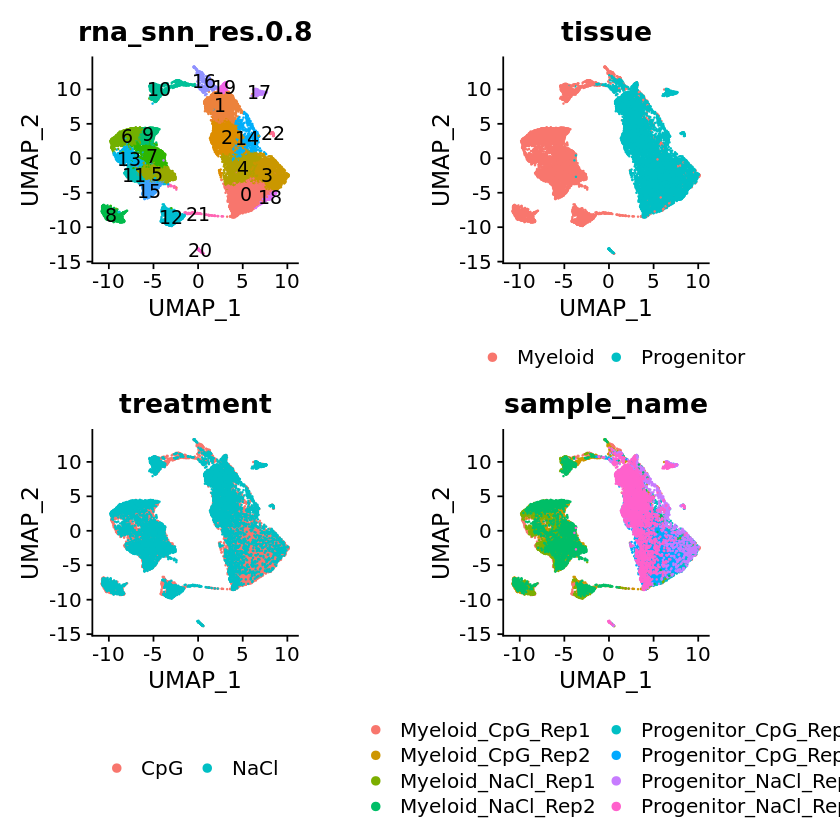

```r
reduction <- "rna_umap_nno"

dplot_1 <- DimPlot(so_qc, reduction = reduction, group.by = "rna_snn_res.0.8", label = TRUE) & theme(aspect.ratio = 1, legend.position = "none")
dplot_2 <- DimPlot(so_qc, reduction = reduction, group.by = "tissue", label = FALSE) & theme(aspect.ratio = 1, legend.position = "bottom") & guides(color = guide_legend(ncol = 2, override.aes = list(size = 2)))
dplot_3 <- DimPlot(so_qc, reduction = reduction, group.by = "treatment", label = FALSE) & theme(aspect.ratio = 1, legend.position = "bottom") & guides(color = guide_legend(ncol = 2, override.aes = list(size = 2)))
dplot_4 <- DimPlot(so_qc, reduction = reduction, group.by = "sample_name", label = FALSE) & theme(aspect.ratio = 1, legend.position = "bottom") & guides(color = guide_legend(ncol = 2, override.aes = list(size = 2)))

dplot <- dplot_1 + dplot_2 + dplot_3 +  dplot_4 + plot_layout(ncol = 2)
dplot
ggsave(dplot, filename = "result/plot/seurat/dimplot_1.png", width = 9, height = 9)
```

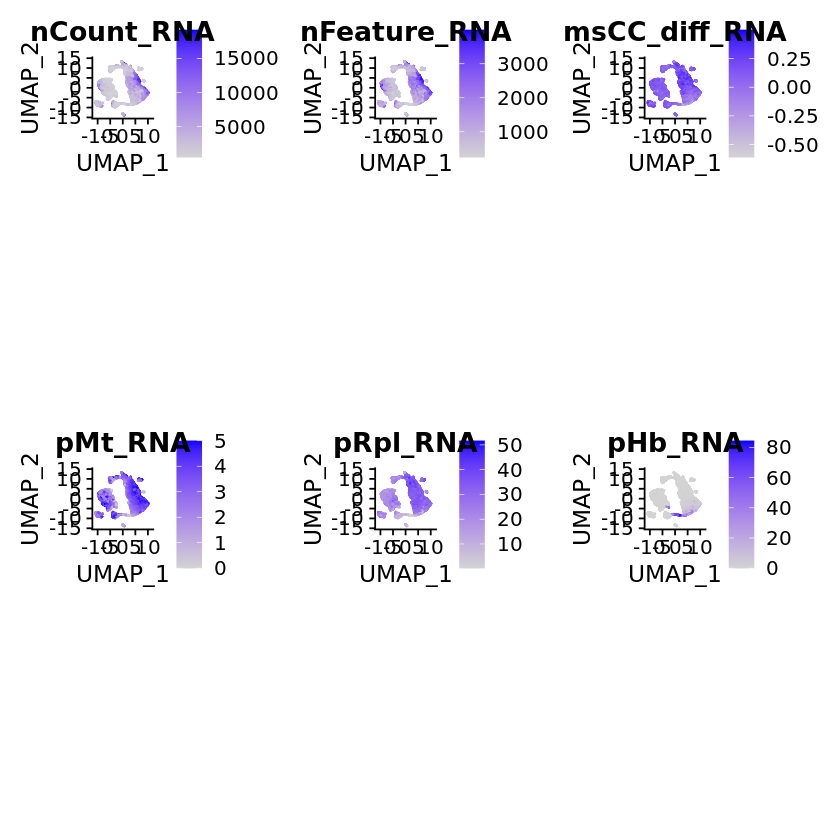

```r
fplot_1 <- FeaturePlot(so_qc, reduction = reduction, features = "nCount_RNA") & theme(aspect.ratio = 1)
fplot_2 <- FeaturePlot(so_qc, reduction = reduction, features = "nFeature_RNA") & theme(aspect.ratio = 1)
fplot_3 <- FeaturePlot(so_qc, reduction = reduction, features = "msCC_diff_RNA") & theme(aspect.ratio = 1)
fplot_4 <- FeaturePlot(so_qc, reduction = reduction, features = "pMt_RNA") & theme(aspect.ratio = 1)
fplot_5 <- FeaturePlot(so_qc, reduction = reduction, features = "pRpl_RNA") & theme(aspect.ratio = 1)
fplot_6 <- FeaturePlot(so_qc, reduction = reduction, features = "pHb_RNA") & theme(aspect.ratio = 1)

fplot <- fplot_1 + fplot_2 + fplot_3 + fplot_4 + fplot_5 + fplot_6 + plot_layout(ncol = 3)
fplot
ggsave(fplot, filename = "result/plot/seurat/fplot_1.png", width = 9, height = 6)
```

# Bar plot cluster overlap

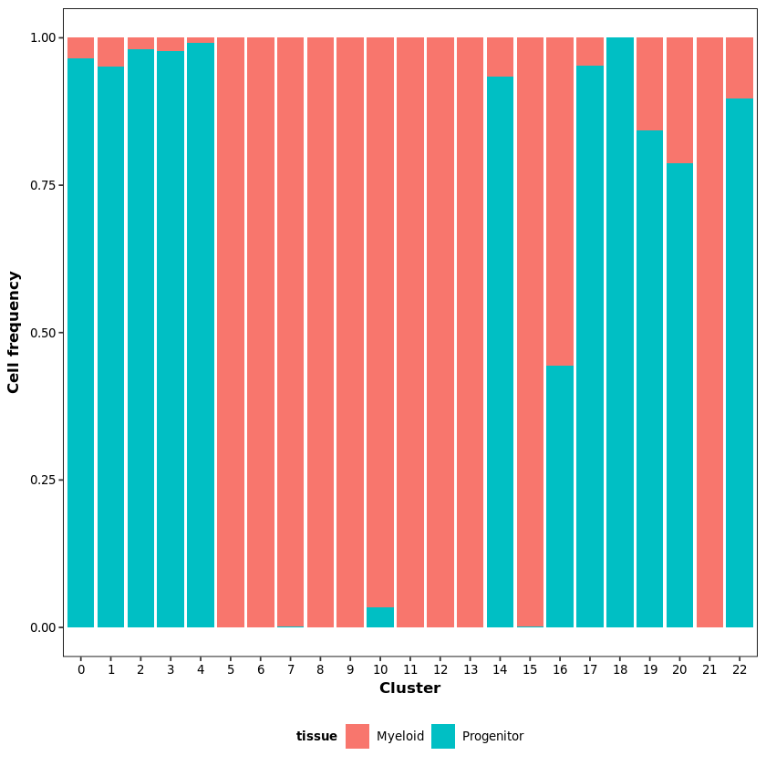

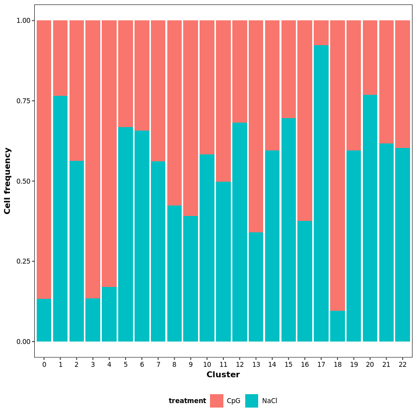

```r
cluster_tissue <- ggplot(so_qc@meta.data, aes(x = seurat_clusters, fill = tissue)) +
  geom_bar(stat = "count", position = "fill") +
  #scale_fill_manual(values = so_color$cell_type) +
  ggtitle("Cluster frequency") + xlab("Cluster") + ylab("Cell frequency") +
  theme(legend.position = "bottom")

cluster_treatment <- ggplot(so_qc@meta.data, aes(x = seurat_clusters, fill = treatment)) +
  geom_bar(stat = "count", position = "fill") +
  #scale_fill_manual(values = so_color$phenotype) +
  ggtitle("Cluster frequency") + xlab("Cluster") + ylab("Cell frequency") +
  theme(legend.position = "bottom")

cluster_tissue
cluster_treatment

ggsave(cluster_tissue, filename = "result/plot/seurat/cluster_tissue.png", width = 6, height = 3)
ggsave(cluster_treatment, filename = "result/plot/seurat/cluster_treatment.png", width = 6, height = 3)
```

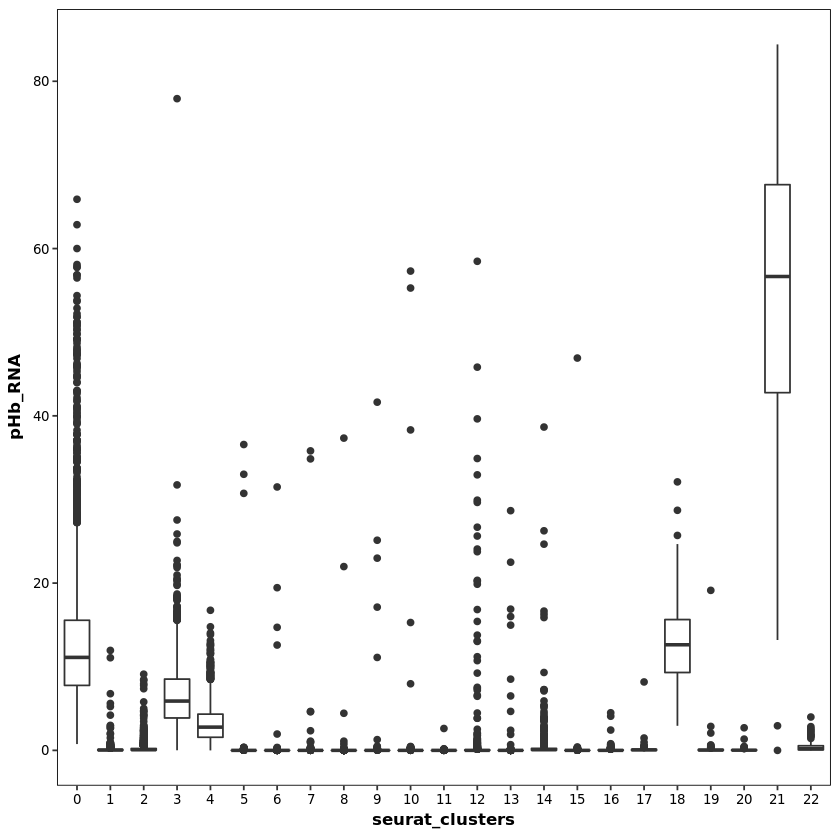

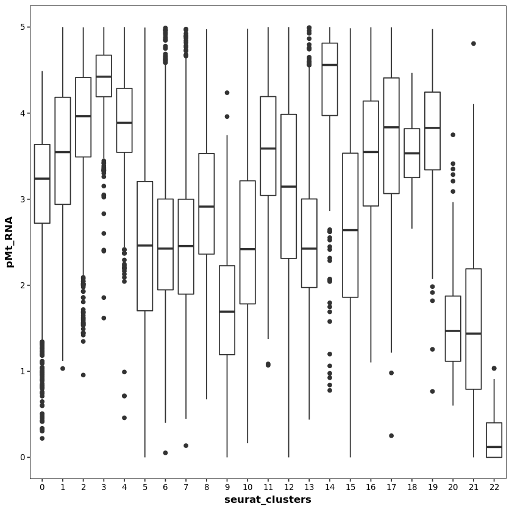

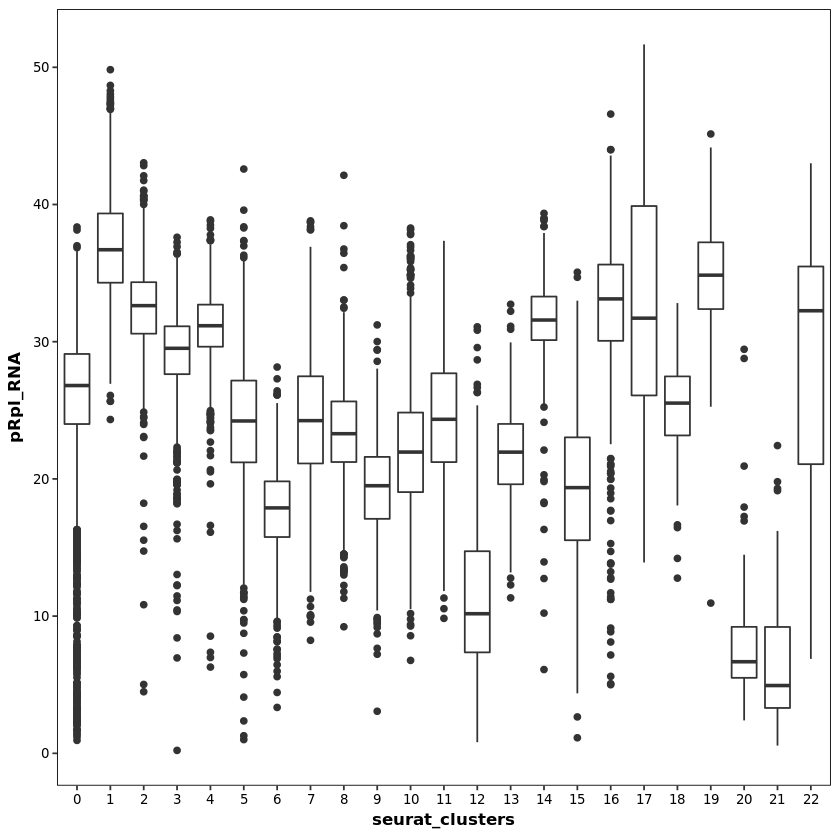

```r
ggplot(so_qc@meta.data, aes(x = seurat_clusters, y = pHb_RNA)) + geom_boxplot()
ggplot(so_qc@meta.data, aes(x = seurat_clusters, y = pMt_RNA)) + geom_boxplot()
ggplot(so_qc@meta.data, aes(x = seurat_clusters, y = pRpl_RNA)) + geom_boxplot()
```

# Cluster marker

## FACS marker

CD45 - Ptprc for Immune cells Erythroblast marker CD71 Tfrc CD71 is an integral membrane protein that mediates the uptake of transferrin iron complexes

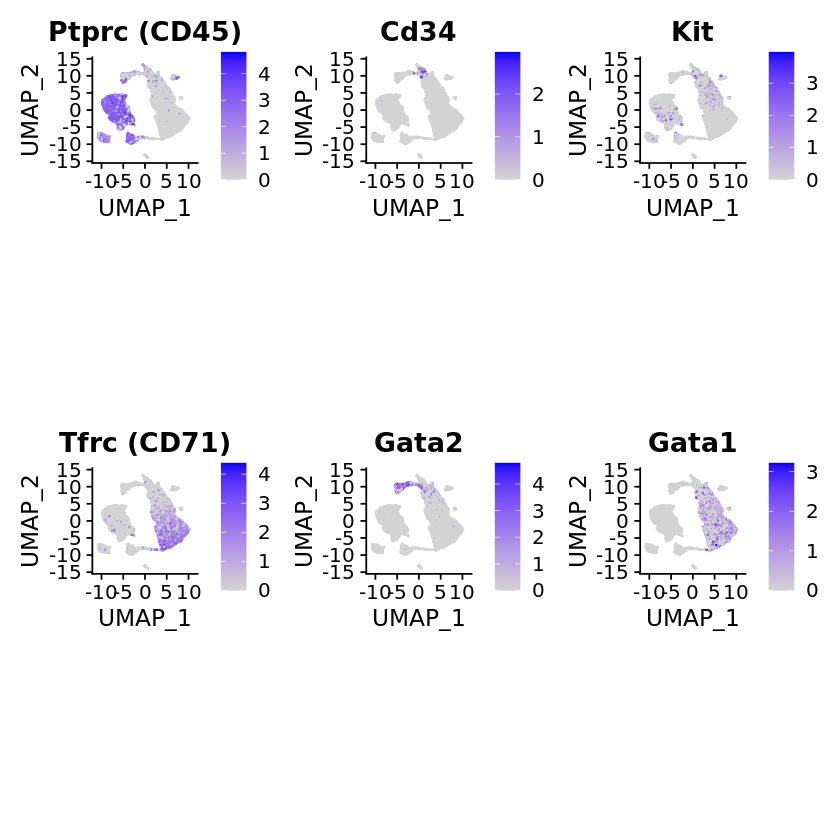

```r
fplot_1 <- FeaturePlot(so_qc, reduction = reduction, features = "Ptprc") & theme(aspect.ratio = 1) & ggtitle("Ptprc (CD45)")
fplot_2 <- FeaturePlot(so_qc, reduction = reduction, features = "Cd34") & theme(aspect.ratio = 1) & ggtitle("Cd34")
fplot_3 <- FeaturePlot(so_qc, reduction = reduction, features = "Kit") & theme(aspect.ratio = 1) & ggtitle("Kit")
fplot_4 <- FeaturePlot(so_qc, reduction = reduction, features = "Tfrc") & theme(aspect.ratio = 1) & ggtitle("Tfrc (CD71)")
fplot_5 <- FeaturePlot(so_qc, reduction = reduction, features = "Gata2") & theme(aspect.ratio = 1) & ggtitle("Gata2")
fplot_6 <- FeaturePlot(so_qc, reduction = reduction, features = "Gata1") & theme(aspect.ratio = 1) & ggtitle("Gata1")

fplot <- fplot_1 + fplot_2 + fplot_3 + fplot_4 + fplot_5 + fplot_6 + plot_layout(ncol = 3)
fplot
ggsave(fplot, filename = "result/plot/seurat/fplot_2.png", width = 9, height = 6)
```

## Histocompatibility Class I

H2-K1 - Class I histocompatibility antigen, kappa-B alpha chain H2-D1 - Class I histocompatibility antigen, D-B alpha chain H2-L1 - not found

## Histocompatibility Class II

H2-Aa - Class II histocompatibility antigen, A-B alpha chain H2-Ab1 - Class II histocompatibility antigen, A beta chain

H2-Eb1 - Class II histocompatibility antigen, I-E beta chain H2-Eb2 - Class II histocompatibility antigen, E beta chain

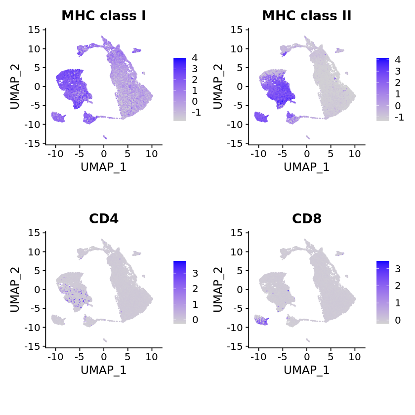

```r
mhcI_genes <- c("H2-K1", "H2-D1")
mhcII_genes <- c("H2-Aa", "H2-Ab1", "H2-Eb1", "H2-Eb2")
cd4_genes <- c("Cd4")
cd8_genes <- c("Cd8a")

so_qc <- AddModuleScore(so_qc, features = list(mhcI_genes), assays = "RNA", slot = "data", ctrl = 100, nbin = 25, name = "msMHCI_RNA")
so_qc <- AddModuleScore(so_qc, features = list(mhcII_genes), assays = "RNA", slot = "data", ctrl = 100, nbin = 25, name = "msMHCII_RNA")
so_qc <- AddModuleScore(so_qc, features = list(cd4_genes), assays = "RNA", slot = "data", ctrl = 100, nbin = 25, name = "msCd4_RNA")
so_qc <- AddModuleScore(so_qc, features = list(cd8_genes), assays = "RNA", slot = "data", ctrl = 100, nbin = 25, name = "msCd8_RNA")

fplot_mhcI <- FeaturePlot(so_qc, reduction = reduction, features = "msMHCI_RNA1") & theme(aspect.ratio = 1) & ggtitle("MHC class I")
fplot_mhcII <- FeaturePlot(so_qc, reduction = reduction, features = "msMHCII_RNA1") & theme(aspect.ratio = 1) & ggtitle("MHC class II")
fplot_cd4 <- FeaturePlot(so_qc, reduction = reduction, features = "msCd4_RNA1") & theme(aspect.ratio = 1) & ggtitle("CD4")
fplot_cd8 <- FeaturePlot(so_qc, reduction = reduction, features = "msCd8_RNA1") & theme(aspect.ratio = 1) & ggtitle("CD8")

fplot_mhc <- fplot_mhcI + fplot_mhcII + fplot_cd4 + fplot_cd8 + plot_layout(ncol = 2)
fplot_mhc
ggsave(fplot_mhc, filename = "result/plot/seurat/fplot_mhc.png", width = 6, height = 6)
```

## T-cell TCR-CD3 complex

Trac - T cell receptor alpha constant Trbc1 - T cell receptor beta constant 1 Trbc2 - T cell receptor beta constant 2 Trdc - T cell receptor delta constant Trgc1 - T cell receptor gamma constant 1 Trgc2 - T cell receptor gamma constant 2

Cd247 - T-cell surface glycoprotein Cd3 zeta chain (Cd3z) Cd3g - T-cell surface glycoprotein Cd3 gamma chain Cd3e - T-cell surface glycoprotein Cd3 epsilon chain Cd3d - T-cell surface glycoprotein Cd3 delta chain

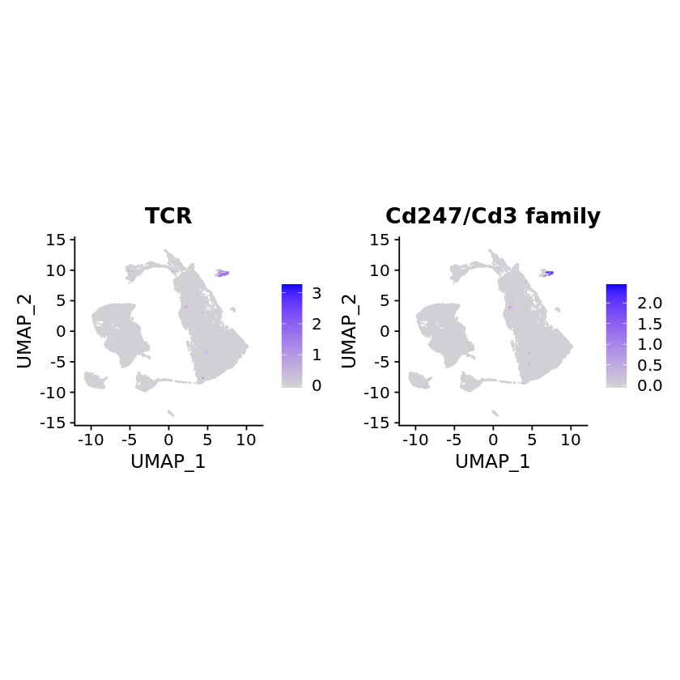

```r
tcr_genes <- c("Trac", "Trbc1", "Trbc2", "Trdc", "Trgc1", "Trgc2")
tcr_cd3_genes <- c("Cd247", "Cd3g", "Cd3e", "Cd3d")

so_qc <- AddModuleScore(so_qc, features = list(tcr_genes), assays = "RNA", slot = "data", ctrl = 100, nbin = 25, name = "msTcr_RNA")
so_qc <- AddModuleScore(so_qc, features = list(tcr_cd3_genes), assays = "RNA", slot = "data", ctrl = 100, nbin = 25, name = "msTcr_cd3_RNA")

fplot_tcr <- FeaturePlot(so_qc, reduction = reduction, features = "msTcr_RNA1") & theme(aspect.ratio = 1) & ggtitle("TCR")
fplot_tcr_cd3 <- FeaturePlot(so_qc, reduction = reduction, features = "msTcr_cd3_RNA1") & theme(aspect.ratio = 1) & ggtitle("Cd247/Cd3 family")

fplot_tcr_cd3 <- fplot_tcr + fplot_tcr_cd3 + plot_layout(ncol = 2)
fplot_tcr_cd3
ggsave(fplot_tcr_cd3, filename = "result/plot/seurat/fplot_tcr_cd3.png", width = 6, height = 3)
```

## B-cell Immonogloblin complex

Naive B-cells produce the following Ig classes: Ighm - Immunoglobulin heavy constant mu (naive B-cells) Ighd - Immunoglobulin heavy constant delta (naive B-cells)

Through isotope switching the following Ig classes can be produced: Ighg1 - Immunoglobulin heavy constant gamma (Mouse with Igh1b have Igg2c isotope instead of Igg2a) Ighg2a - Immunoglobulin heavy constant gamma (NA) Ighg2b - Immunoglobulin heavy constant gamma Ighg2c - Immunoglobulin heavy constant gamma Ighg3 - Immunoglobulin heavy constant gamma Igha - Immunoglobulin heavy constant alpha Ighe - Immunoglobulin heavy constant epsilon (NA)

Igkc - Immunoglobulin kappa constant (light chain) Iglc - Immunoglobulin lambda constant (light chain)

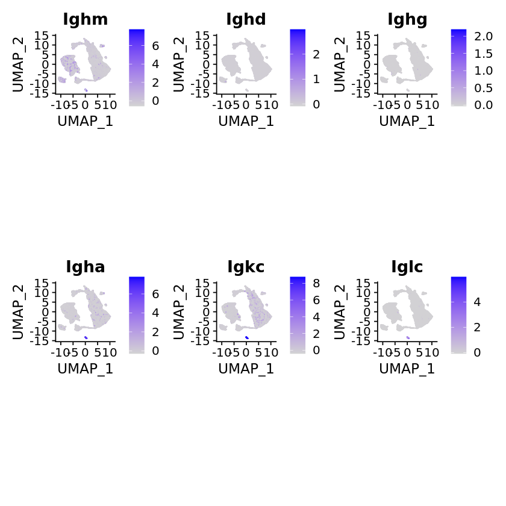

```r
Ighm_genes <- c("Ighm")
Ighd_genes <- c("Ighd")
Ighg_genes <- c("Ighg1", "Ighg2a", "Ighg2b", "Ighg2c", "Ighg3")
Igha_genes <- c("Igha")
Ighe_genes <- c("Ighe")
Igkc_genes <- c("Igkc")
Iglc_genes <- c("Iglc1", "Iglc2", "Iglc3")

so_qc <- AddModuleScore(so_qc, features = list(Ighm_genes), assays = "RNA", slot = "data", ctrl = 100, nbin = 25, name = "msIghm_RNA")
so_qc <- AddModuleScore(so_qc, features = list(Ighd_genes), assays = "RNA", slot = "data", ctrl = 100, nbin = 25, name = "msIghd_RNA")
so_qc <- AddModuleScore(so_qc, features = list(Ighg_genes), assays = "RNA", slot = "data", ctrl = 100, nbin = 25, name = "msIghg_RNA")
so_qc <- AddModuleScore(so_qc, features = list(Igha_genes), assays = "RNA", slot = "data", ctrl = 100, nbin = 25, name = "msIgha_RNA")
#so_qc <- AddModuleScore(so_qc, features = list(Ighe_genes), assays = "RNA", slot = "data", ctrl = 100, nbin = 25, name = "msIghe_RNA")
so_qc <- AddModuleScore(so_qc, features = list(Igkc_genes), assays = "RNA", slot = "data", ctrl = 100, nbin = 25, name = "msIgkc_RNA")
so_qc <- AddModuleScore(so_qc, features = list(Iglc_genes), assays = "RNA", slot = "data", ctrl = 100, nbin = 25, name = "msIglc_RNA")


fplot_Ighm <- FeaturePlot(so_qc, reduction = reduction, features = "msIghm_RNA1") & theme(aspect.ratio = 1) & ggtitle("Ighm")
fplot_Ighd <- FeaturePlot(so_qc, reduction = reduction, features = "msIghd_RNA1") & theme(aspect.ratio = 1) & ggtitle("Ighd")
fplot_Ighg <- FeaturePlot(so_qc, reduction = reduction, features = "msIghg_RNA1") & theme(aspect.ratio = 1) & ggtitle("Ighg")
fplot_Igha <- FeaturePlot(so_qc, reduction = reduction, features = "msIgha_RNA1") & theme(aspect.ratio = 1) & ggtitle("Igha")
fplot_Igkc <- FeaturePlot(so_qc, reduction = reduction, features = "msIgkc_RNA1") & theme(aspect.ratio = 1) & ggtitle("Igkc")
fplot_Iglc <- FeaturePlot(so_qc, reduction = reduction, features = "msIglc_RNA1") & theme(aspect.ratio = 1) & ggtitle("Iglc")

fplot_ig <- fplot_Ighm + fplot_Ighd + fplot_Ighg + fplot_Igha + fplot_Igkc + fplot_Iglc + plot_layout(ncol = 3)
fplot_ig

ggsave(fplot_ig, filename = "result/plot/seurat/fplot_ig.png", width = 9, height = 6)
```

# Save output

```r
saveRDS(so_qc, so_qc_file)
```